# working with confounding variables

# 3 Confounding

```r
library(tidyverse)
library(broom)
```

## 3.1 Correlation is not causation

Spurious correlation

- this is data dredging or cherry picking data.

example using monte carlo method

P-hacking is an issue in scientific literature.

- because journals are biased toward positive tests over negative tests. In other words, they are biased towards scientific results that show correlation. Researchers are insentivised to use statistical methods that have low p-values.
- some examples of p-hacking:
  - in epidimeology and other social sciences researchers may look for correlation between an average out come and several exposures, but only report the exposure that results in the small p-value
  - fitting several different models that account for confounding but only report the model that results in the smallest p-value.

```r
N <- 25
g<- 1000

sim_data <- tibble(group = rep(1:g, each = N), x = rnorm(N * g), y = rnorm(N * g))

# calculate the correltatoin for each group
res <- sim_data |>
  group_by(group) |>
  summarise(r = cor(x, y)) |>
  arrange(desc(r))
res
```

```
# A tibble: 1,000 × 2
   group     r
   <int> <dbl>
 1   297 0.551
 2   435 0.541
 3   730 0.540
 4   666 0.524
 5    90 0.512
 6   723 0.491
 7   561 0.490
 8   994 0.488
 9   312 0.488
10   775 0.485
# ℹ 990 more rows
```

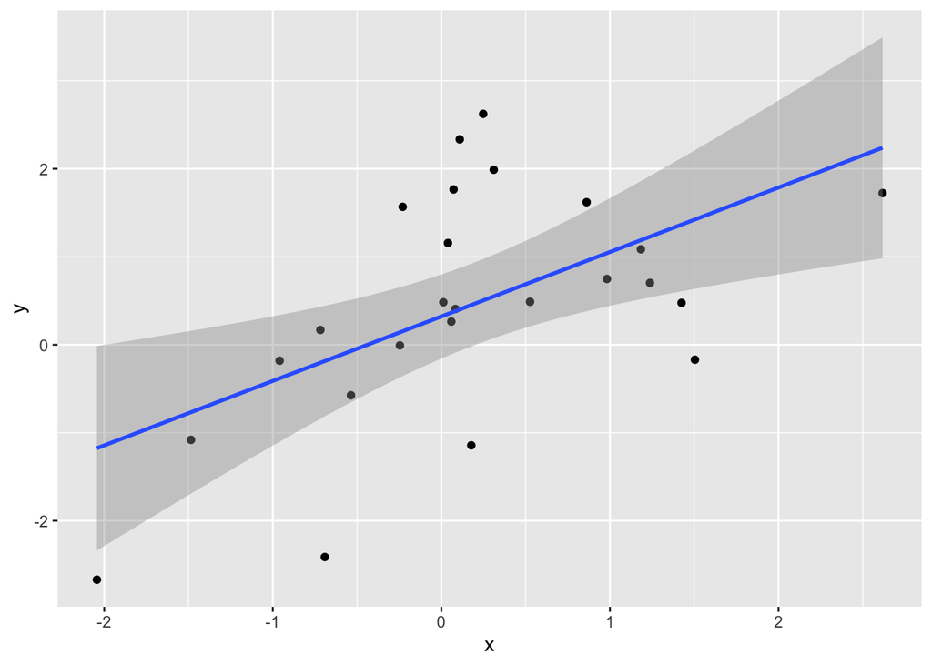

```r
# graph points from the data set with maximum correlation

sim_data |>
  filter(
    group == pull(slice_max(res, r), group) # filter for group with highest cor.
  ) |>
  ggplot(aes(x,y)) +
  geom_point() +
  geom_smooth(method = "lm")
```

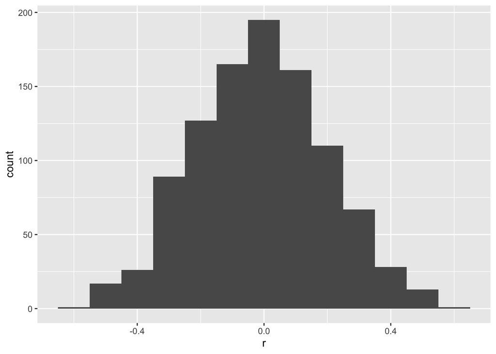

```r
#hist of group correlation in monte carlo simulation
res |>
  ggplot(aes(x = r)) +
  geom_histogram(binwidth = 0.1)
```

```r
# linear model for group with highest r
sim_data |>
  filter(
    group == pull(slice_max(res,r), group)
  ) |>
  summarize(tidy(lm(y ~ x)))
```

```
# A tibble: 2 × 5
  term        estimate std.error statistic p.value
  <chr>          <dbl>     <dbl>     <dbl>   <dbl>
1 (Intercept)    0.322     0.231      1.39 0.177
2 x              0.733     0.231      3.17 0.00428
```

## 3.2 outliers

Outliers can effect the correlation coeffecient.

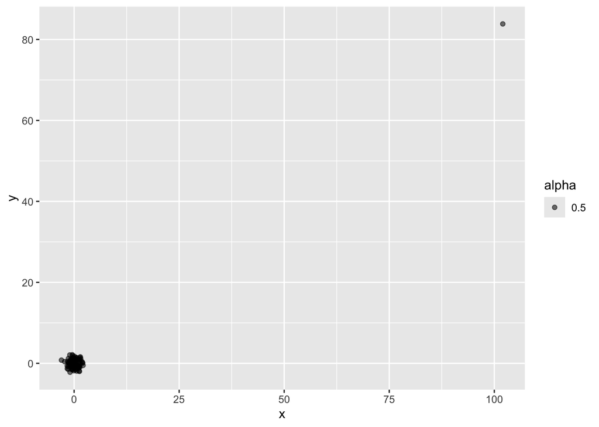

```r
# simulate independent X, Y and standardize all except entry 23
# note that you may get different values than those shown in the video depending on R
set.seed(1985)
x <- rnorm(100,100,1)
y <- rnorm(100,84,1)
x[-23] <- scale(x[-23])
y[-23] <- scale(y[-23])

# plot to show the outlier

qplot(x, y, alpha = 0.5)
```

```r
# cor would be 0 or close to 0 with no outlier but because f of the outlier there appears to be strong correlation, but when remove it the calue is almost zero

cor(x,y)
```

```
[1] 0.9878382
```

```r
cor(x[-23], y[-23])
```

```
[1] -0.04419032
```

### Spearman correlation:

the Spearman correlation calculation ranks the each data point in the data sets. This accounts for outliers

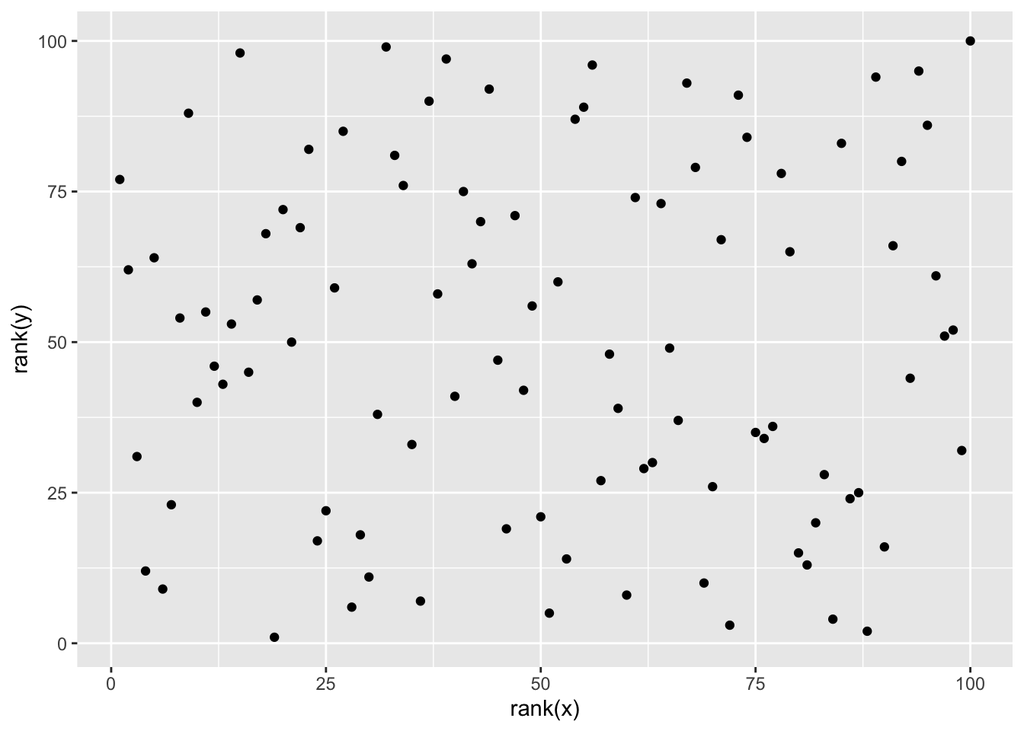

```r
qplot(rank(x), rank(y))
```

```r
cor(rank(x), rank(y))
```

```
[1] 0.002508251
```

```r
# you can use the spearman correlation calculation within the cor() function
cor(x, y, method = "spearman")
```

```
[1] 0.002508251
```

### 3.3 Reversing correlation and causation:

saying that not being tutored lowers test scores instead of saying being tutored raises test stars

or

saying that a tall son causes a tall father

so

intepretation requires common sense

## 3.4 confounders

**most common reason correlations are misinterpreted**

### Men vs. women acceptance rate for UC Berkeley in1973 as an example of misinterpreting correlation

- this is an examples of Simpsons paradox which is explained in the next video.

looking at over all acceptance men are more likely than women to be accepted.

- a chi-squared test clearly reject the hypothesis that acceptance and gender are independent and has a very low p-value

**BUT**

when we look at the data more closely we see that women applied more to the low acceptance rate majors while men applied to the higher acceptance rate majors.

```r
library(dslabs)
data(admissions)
admissions
```

```
   major gender admitted applicants
1      A    men       62        825
2      B    men       63        560
3      C    men       37        325
4      D    men       33        417
5      E    men       28        191
6      F    men        6        373
7      A  women       82        108
8      B  women       68         25
9      C  women       34        593
10     D  women       35        375
11     E  women       24        393
12     F  women        7        341
```

```r
# calculate women vs. men admitted
admissions |> colnames()
```

```
[1] "major"      "gender"     "admitted"   "applicants"
```

```r
admissions |>
  group_by(gender) |>
  summarize(
          percentage = round(sum(admitted * applicants)/sum(applicants), 1))
```

```
# A tibble: 2 × 2
  gender percentage
  <chr>       <dbl>
1 men          44.5
2 women        30.3
```

```r
# test if admission and geneder are independent
admissions |>
  group_by(gender) |>
  summarize(total_admitted = round(sum(admitted / 100 * applicants)),
            not_admitted = round(sum((100- admitted) / 100 * applicants))) |>
  select(-gender) %>%
  summarize(tidy(chisq.test(.)))
```

```
# A tibble: 1 × 4
  statistic  p.value parameter method
      <dbl>    <dbl>     <int> <chr>
1      91.6 1.06e-21         1 Pearson's Chi-squared test with Yates' continuit…
```

```r
# percent by major

admissions |>
  select(gender, major, admitted) |>
  pivot_wider(names_from = gender, values_from = admitted) |>
  mutate(women_minus_men = women - men)
```

```
# A tibble: 6 × 4
  major   men women women_minus_men
  <chr> <dbl> <dbl>           <dbl>
1 A        62    82              20
2 B        63    68               5
3 C        37    34              -3
4 D        33    35               2
5 E        28    24              -4
6 F         6     7               1
```

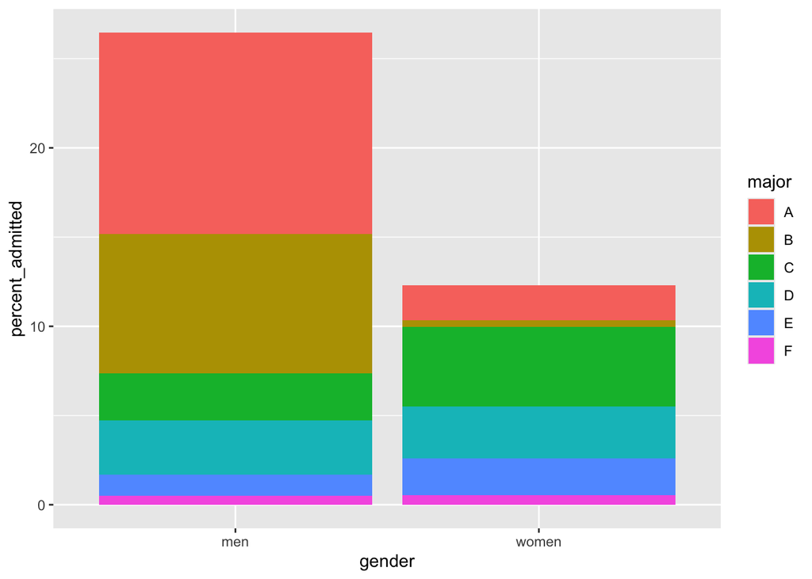

```r
# plot % of applicants admitted by gender
admissions |>
  mutate(percent_admitted = admitted * applicants / sum(applicants)) |>
  ggplot(aes(gender, y = percent_admitted, fill = major)) +
  geom_bar(stat = "identity", position = "stack")
```

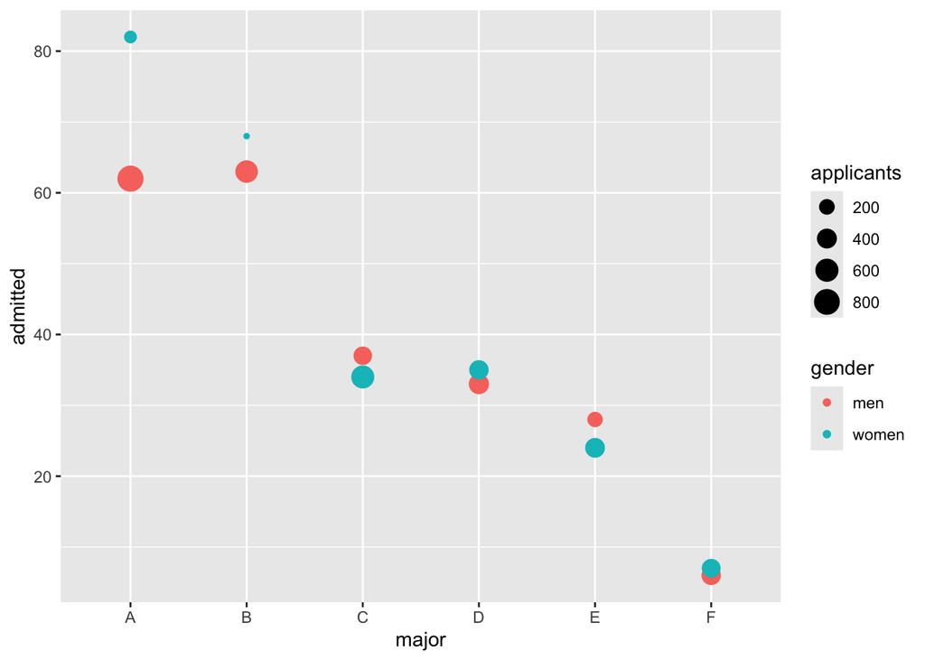

```r
# from this we can see that a majority of the men admitted com from major A and B


# plot admissions stratified by major

admissions |>
  ggplot(aes(major, admitted, color = gender, size = applicants)) +
  geom_point()
```

```r
#avaerage aditted rate across majors by gender
admissions |>
  group_by(gender) |>
  summarize(average = round(mean(admitted), 1))
```

```
# A tibble: 2 × 2
  gender average
  <chr>    <dbl>
1 men       38.2
2 women     41.7
```